# Clustering samples

Bruno de Medeiros

7/16/2018

We used PCANGSD to obtain variance-covariance matrices for our samples. Now we will use these to get their eigenvalues and eigenvectors, and use k-means to cluster. This is similar to what R package adegenet does (we will steal some commands from find.clusters), but by using ANGSD we are able to include loci sequenced at low coverage and imputing for missign data is not simply the average allele frequencies, but it is informed by the other alleles as well.

# Load packages

Let’s start by reading packages:

```r
library(raster)
library(rnaturalearth)
library(sf)
library(adegenet)
library(tidyverse)
library(ggthemes)
library(RStoolbox)
library(scales)
library(xtable)
library(ggrepel)
rm(list=ls())
```

# Load sample ids

PCANGSD does not list sample names in the variance/covariance matrix, so we will have to read these from the list of bam files passed to ANGSD first.

```r
spp = list.dirs(file.path('..','ANGSD_weevils/PCA'),recursive = F,full.names = F)
names(spp) = str_c(spp,'_')
insect_specimens = spp %>%
  sapply(function(x){
    list.files(file.path('..','ANGSD_weevils/PCA',x),
               pattern = '^bam.filelist',
               recursive = T,
               full.names = T) %>%
      file() %>%
      readLines() %>%
      basename() %>%
      str_remove_all('\\..+$')
  }) %>%
  unlist
sample_names = tibble(sample = insect_specimens,
                      taxon = names(insect_specimens) %>% str_remove('_[0-9]+$'))
sample_names
```

| sample | taxon |
| --- | --- |
| BdM1012 | Anchylorhynchus_1 |
| BdM1013 | Anchylorhynchus_1 |
| BdM1014 | Anchylorhynchus_1 |
| BdM1015 | Anchylorhynchus_1 |
| BdM1016 | Anchylorhynchus_1 |
| BdM1017 | Anchylorhynchus_1 |
| BdM1018 | Anchylorhynchus_1 |
| BdM1019 | Anchylorhynchus_1 |
| BdM1031 | Anchylorhynchus_1 |
| BdM1034 | Anchylorhynchus_1 |

[output cut: 326 more lines]

```r
#we will use this later
names(spp) = spp
```

# Compute eigenvalues and eigenvectors

Let’s now load variance/covariance matrices

```r
covs = spp %>%
  plyr::llply(function(x){
    list.files(file.path('..','ANGSD_weevils/PCA',x),
               pattern = '.+pca\\.cov',
               recursive = T,
               full.names = T) %>%
      file %>%
      readr::read_lines() %>%
      plyr::laply(str_split,'[:space:]',simplify = T) %>%
      as.numeric %>%
      matrix(.,nrow=sqrt(length(.)))
  })
str(covs)
```

```
List of 13
 $ Anchylorhynchus_1: num [1:47, 1:47] 1.767 0.944 0.971 0.979 0.956 ...
 $ Anchylorhynchus_2: num [1:36, 1:36] 1.008 0.172 0.15 0.157 0.172 ...
 $ Anchylorhynchus_3: num [1:5, 1:5] 0.9047 -0.0259 -0.2851 -0.3014 -0.0161 ...
 $ Andranthobius_1  : num [1:38, 1:38] 1.0154 0.0407 -0.0385 -0.0374 0.0368 ...
 $ Andranthobius_2  : num [1:22, 1:22] 1.09977 0.05116 -0.12288 -0.01015 0.00696 ...
 $ C_decolor_1      : num [1:20, 1:20] 1.4949 0.4707 0.0408 -0.2987 -0.3124 ...
 $ C_decolor_2      : num [1:9, 1:9] 0.9128 0.1286 -0.1692 -0.1377 0.0303 ...
 $ C_impar          : num [1:47, 1:47] 2.23 1.17 1.12 1.11 1.15 ...
 $ D_polyphaga      : num [1:18, 1:18] 2.223 1.25 1.33 -0.323 -0.24 ...
 $ M_bondari_1      : num [1:23, 1:23] 0.94403 0.01905 0.02326 -0.00108 0.02011 ...
 $ M_ypsilon        : num [1:27, 1:27] 0.9798 0.0135 -0.017 -0.0132 -0.0236 ...
 $ P_cocoseae       : num [1:26, 1:26] 1.2133 0.217 0.2179 -0.0821 -0.0612 ...
 $ R_rectinasus_1   : num [1:18, 1:18] 1.91 1.192 1.23 1.157 -0.701 ...
```

For each matrix, let’s compute the eigenvalues and eigenvectors.

```r
eig = plyr::llply(covs, eigen, symmetric = T)
str(eig)
```

```
List of 13
 $ Anchylorhynchus_1:List of 2
  ..$ values : num [1:47] 13.68 9.52 1.45 1.27 1.04 ...
  ..$ vectors: num [1:47, 1:47] 0.0839 0.0871 0.0883 0.0874 0.0872 ...
  ..- attr(*, "class")= chr "eigen"
 $ Anchylorhynchus_2:List of 2
  ..$ values : num [1:36] 8.33 1.62 1.5 1.18 1.13 ...
  ..$ vectors: num [1:36, 1:36] -0.144 -0.14 -0.124 -0.132 -0.158 ...
  ..- attr(*, "class")= chr "eigen"
 $ Anchylorhynchus_3:List of 2
  ..$ values : num [1:5] 1.755 0.971 0.951 0.934 0.174
  ..$ vectors: num [1:5, 1:5] 0.323 0.455 -0.506 -0.494 0.434 ...
  ..- attr(*, "class")= chr "eigen"
 $ Andranthobius_1  :List of 2
  ..$ values : num [1:38] 3.49 1.24 1.16 1.11 1.09 ...
  ..$ vectors: num [1:38, 1:38] -0.112 -0.138 0.146 0.103 -0.131 ...
  ..- attr(*, "class")= chr "eigen"
 $ Andranthobius_2  :List of 2
  ..$ values : num [1:22] 3.29 1.17 1.09 1.08 1.07 ...
  ..$ vectors: num [1:22, 1:22] -0.183 -0.2033 0.2442 -0.0564 -0.0633 ...
  ..- attr(*, "class")= chr "eigen"
 $ C_decolor_1      :List of 2
  ..$ values : num [1:20] 5.03 1.99 1.14 1.12 1.11 ...
  ..$ vectors: num [1:20, 1:20] -0.276 -0.275 -0.15 0.273 0.276 ...
  ..- attr(*, "class")= chr "eigen"
 $ C_decolor_2      :List of 2
  ..$ values : num [1:9] 2.743 1.227 1.016 0.929 0.919 ...
  ..$ vectors: num [1:9, 1:9] -0.219 -0.374 0.357 0.285 -0.337 ...
  ..- attr(*, "class")= chr "eigen"
 $ C_impar          :List of 2
  ..$ values : num [1:47] 10.75 6.56 3.82 1.41 1.17 ...
  ..$ vectors: num [1:47, 1:47] -0.341 -0.347 -0.338 -0.34 -0.341 ...
  ..- attr(*, "class")= chr "eigen"
 $ D_polyphaga      :List of 2
  ..$ values : num [1:18] 7.365 1.275 1.093 0.996 0.966 ...
  ..$ vectors: num [1:18, 1:18] -0.4525 -0.4402 -0.4669 0.1058 0.0774 ...
  ..- attr(*, "class")= chr "eigen"
 $ M_bondari_1      :List of 2
  ..$ values : num [1:23] 8.59 1.5 1.24 1.1 1.09 ...
  ..$ vectors: num [1:23, 1:23] -0.069 -0.0669 -0.0709 -0.0664 -0.0645 ...
  ..- attr(*, "class")= chr "eigen"
 $ M_ypsilon        :List of 2
  ..$ values : num [1:27] 6.28 1.4 1.19 1.15 1.13 ...
  ..$ vectors: num [1:27, 1:27] -0.0661 -0.0227 0.0307 0.035 0.03 ...
  ..- attr(*, "class")= chr "eigen"
 $ P_cocoseae       :List of 2
  ..$ values : num [1:26] 2.69 1.39 1.26 1.16 1.15 ...
  ..$ vectors: num [1:26, 1:26] -0.3768 -0.344 -0.3502 0.0538 0.0356 ...
  ..- attr(*, "class")= chr "eigen"
 $ R_rectinasus_1   :List of 2
  ..$ values : num [1:18] 13.561 1.275 0.951 0.911 0.771 ...
  ..$ vectors: num [1:18, 1:18] -0.307 -0.299 -0.321 -0.305 0.176 ...
  ..- attr(*, "class")= chr "eigen"
```

# K-means clustering

We will now use a modified version of adegenet’s function `find.clusters` to find the optimal number of clusters for each species. Let’s define the function first:

```r
find.clusters.eigen = function (x, n.pca = NULL, n.clust = NULL, method = c("kmeans",
    "ward"), stat = c("BIC", "AIC", "WSS"), choose.n.clust = TRUE,
    criterion = c("diffNgroup", "min", "goesup", "smoothNgoesup",
        "goodfit"), max.n.clust = round(nrow(x)/10), n.iter = 1e+05,
    n.start = 10, center = TRUE, scale = TRUE, pca.select = c("nbEig",
        "percVar"), perc.pca = NULL, ..., dudi = NULL)
{
    .compute.wss = adegenet:::.compute.wss
    stat <- match.arg(stat)
    pca.select <- match.arg(pca.select)
    criterion <- match.arg(criterion)
    min.n.clust <- 2
    max.n.clust <- max(max.n.clust, 2)
    method <- match.arg(method)


    N <- nrow(x$vectors)
    # REDUCEDIM <- is.null(dudi)
    # if (REDUCEDIM) {
    #     maxRank <- min(dim(x))
    #     pcaX <- dudi.pca(x, center = center, scale = scale, scannf = FALSE,
    #         nf = maxRank)
    # }
    # else {
    #     pcaX <- dudi
    # }
    cumVar <- 100 * cumsum(x$values)/sum(x$values)
    #eigenvectors are normalized, adegenet expects them multiplied by sqrt(eigenvalue)
    x$vectors = apply(x$vectors,1,function(y) y * sqrt(x$values)) %>% t
    # if (!REDUCEDIM) {
    #     myCol <- rep(c("black", "lightgrey"), c(ncol(pcaX$li),
    #         length(pcaX$eig)))
    # }
    # else {
        myCol <- "black"
    # }
    if (is.null(n.pca) & pca.select == "nbEig") {
        plot(cumVar, xlab = "Number of retained PCs", ylab = "Cumulative variance (%)",
            main = "Variance explained by PCA", col = myCol)
        cat("Choose the number PCs to retain (>= 1): ")
        n.pca <- as.integer(readLines(con = getOption("adegenet.testcon"),
            n = 1))
    }
    if (is.null(perc.pca) & pca.select == "percVar") {
        plot(cumVar, xlab = "Number of retained PCs", ylab = "Cumulative variance (%)",
            main = "Variance explained by PCA", col = myCol)
        cat("Choose the percentage of variance to retain (0-100): ")
        nperc.pca <- as.numeric(readLines(con = getOption("adegenet.testcon"),
            n = 1))
    }
    if (!is.null(perc.pca)) {
        n.pca <- min(which(cumVar >= perc.pca))
        if (perc.pca > 99.999)
            n.pca <- length(pcaX$eig)
        if (n.pca < 1)
            n.pca <- 1
    }
    X.rank <- length(x$values)
    n.pca <- min(X.rank, n.pca)
    if (n.pca >= N)
        warning("number of retained PCs of PCA is greater than N")
    XU <- x$vectors[, 1:n.pca, drop = FALSE]
    if (is.null(n.clust)) {
        nbClust <- min.n.clust:max.n.clust
        WSS <- numeric(0)
        for (i in 1:length(nbClust)) {
            if (method == "kmeans") {
                temp <- kmeans(XU, centers = nbClust[i], iter.max = n.iter,
                  nstart = n.start)
            }
            else {
                temp <- list()
                temp$cluster <- cutree(hclust(dist(XU)^2, method = "ward.D2"),
                  k = nbClust[i])
            }
            WSS[i] <- .compute.wss(XU, temp$cluster)
        }
        if (stat == "AIC") {
            WSS.ori <- sum(apply(XU, 2, function(v) sum((v -
                mean(v))^2)))
            k <- nbClust
            myStat <- N * log(c(WSS.ori, WSS)/N) + 2 * c(1, nbClust)
            myLab <- "AIC"
            myTitle <- "Value of AIC \nversus number of clusters"
        }
        if (stat == "BIC") {
            WSS.ori <- sum(apply(XU, 2, function(v) sum((v -
                mean(v))^2)))
            k <- nbClust
            myStat <- N * log(c(WSS.ori, WSS)/N) + log(N) * c(1,
                nbClust)
            myLab <- "BIC"
            myTitle <- "Value of BIC \nversus number of clusters"
        }
        if (stat == "WSS") {
            WSS.ori <- sum(apply(XU, 2, function(v) sum((v -
                mean(v))^2)))
            myStat <- c(WSS.ori, WSS)
            myLab <- "Within sum of squares"
            myTitle <- "Value of within SS\nversus number of clusters"
        }
        if (choose.n.clust) {
            plot(c(1, nbClust), myStat, xlab = "Number of clusters",
                ylab = myLab, main = myTitle, type = "o", col = "blue")
            abline(h = 0, lty = 2, col = "red")
            cat("Choose the number of clusters (>=2: ")
            n.clust <- NA
            while (is.na(n.clust)) {
                n.clust <- max(1, as.integer(readLines(con = getOption("adegenet.testcon"),
                  n = 1)))
            }
        }
        else {
            if (criterion == "min") {
                n.clust <- which.min(myStat)
            }
            if (criterion == "goesup") {
                n.clust <- min(which(diff(myStat) > 0))
            }
            if (criterion == "goodfit") {
                temp <- min(myStat) + 0.1 * (max(myStat) - min(myStat))
                n.clust <- min(which(myStat < temp)) - 1
            }
            if (criterion == "diffNgroup") {
                temp <- cutree(hclust(dist(diff(myStat)), method = "ward.D"),
                  k = 2)
                goodgrp <- which.min(tapply(diff(myStat), temp,
                  mean))
                n.clust <- max(which(temp == goodgrp)) + 1
            }
            if (criterion == "smoothNgoesup") {
                temp <- myStat
                temp[2:(length(myStat) - 1)] <- sapply(1:(length(myStat) -
                  2), function(i) mean(myStat[c(i, i + 1, i +
                  2)]))
                n.clust <- min(which(diff(temp) > 0))
            }
        }
    }
    else {
        myStat <- NULL
    }
    if (n.clust > 1) {
        if (method == "kmeans") {
            best <- kmeans(XU, centers = n.clust, iter.max = n.iter,
                nstart = n.start)
        }
        else {
            best <- list()
            best$cluster <- cutree(hclust(dist(XU)^2, method = "ward.D2"),
                k = n.clust)
            best$size <- table(best$cluster)
        }
    }
    else {
        best <- list(cluster = factor(rep(1, N)), size = N)
    }
    if (!is.null(myStat)) {
        names(myStat) <- paste("K", c(1, nbClust), sep = "=")
    }
    res <- list(Kstat = myStat, stat = myStat[n.clust], grp = factor(best$cluster),
        size = best$size)
    return(res)
}
```

```r
clusters = spp %>%
  plyr::llply(function(x){
    find.clusters.eigen(eig[[x]],
                  pca.select = 'percVar',
                  perc.pca=90,
                  max.n.clust = min(10, length(eig[[x]]$values)%/%2))
  },
  .parallel = FALSE)
```

```
Choose the number of clusters (>=2:
```

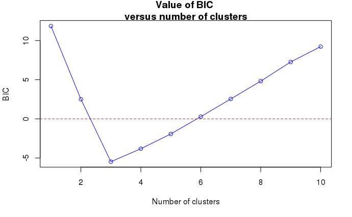

```
Choose the number of clusters (>=2:
```

```r
3
```

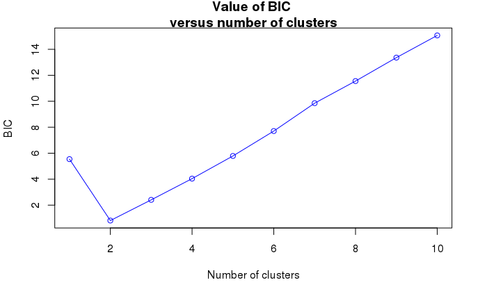

```
Choose the number of clusters (>=2:
```

```r
2
```

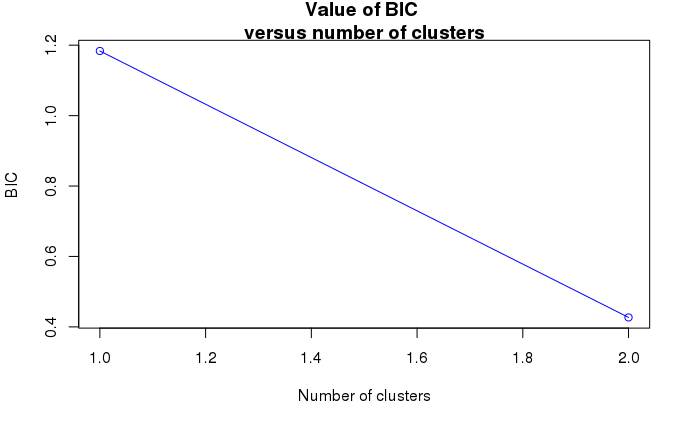

```
Choose the number of clusters (>=2:
```

```r
2
```

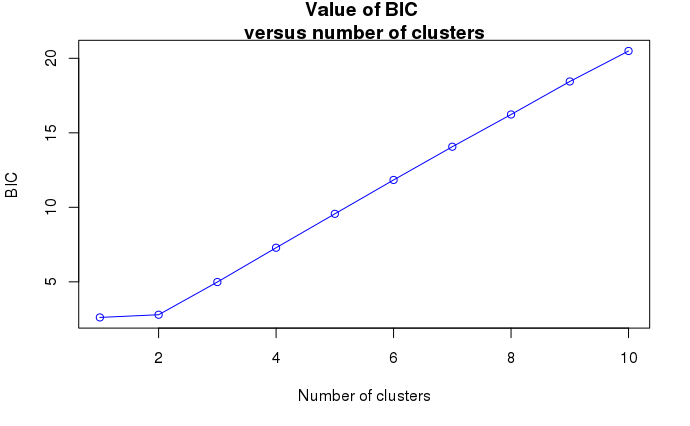

```
Choose the number of clusters (>=2:
```

```r
2
```

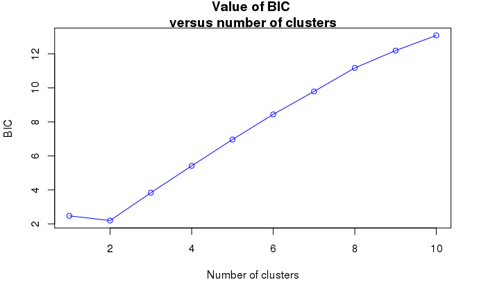

```
Choose the number of clusters (>=2:
```

```r
2
```

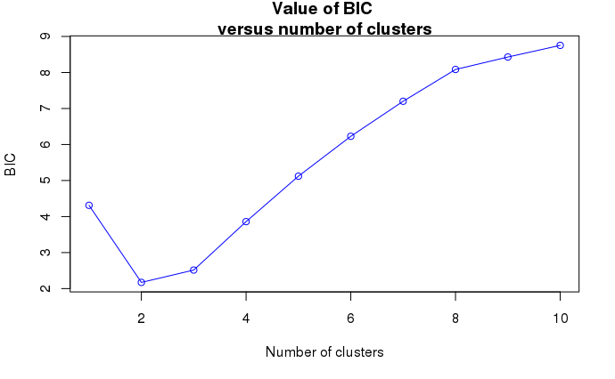

```
Choose the number of clusters (>=2:
```

```r
2
```

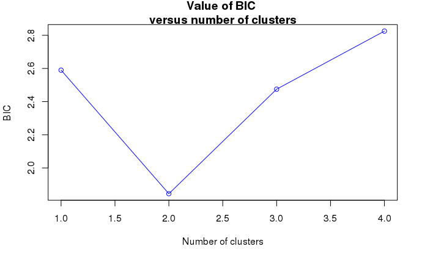

```
Choose the number of clusters (>=2:
```

```r
2
```

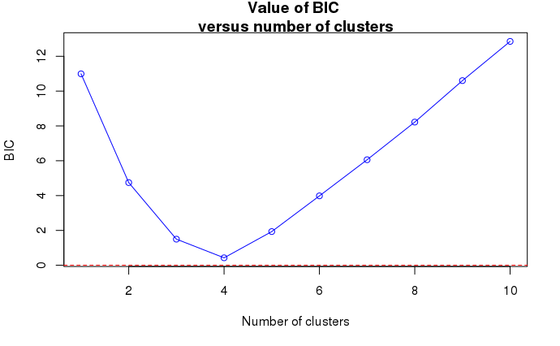

```
Choose the number of clusters (>=2:
```

```r
3
```

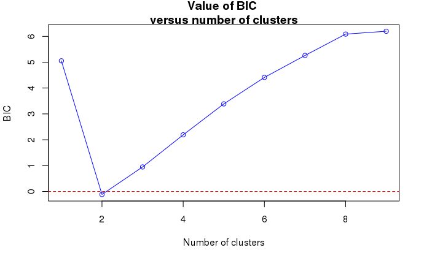

```
Choose the number of clusters (>=2:
```

```r
2
```

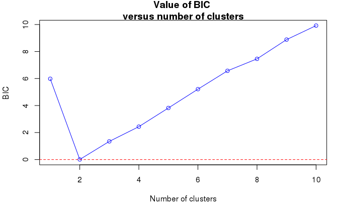

```
Choose the number of clusters (>=2:
```

```r
2
```

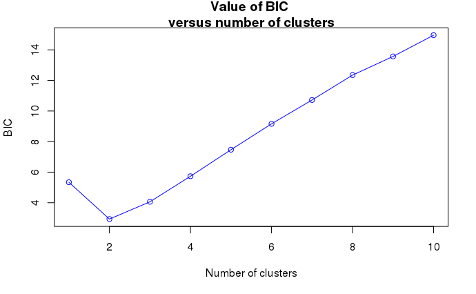

```
Choose the number of clusters (>=2:
```

```r
2
```

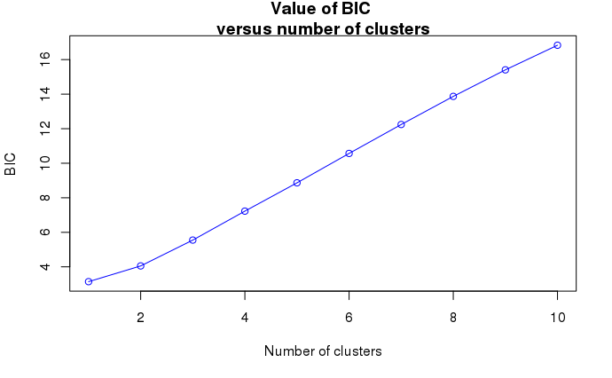

```
Choose the number of clusters (>=2:
```

```r
1
```

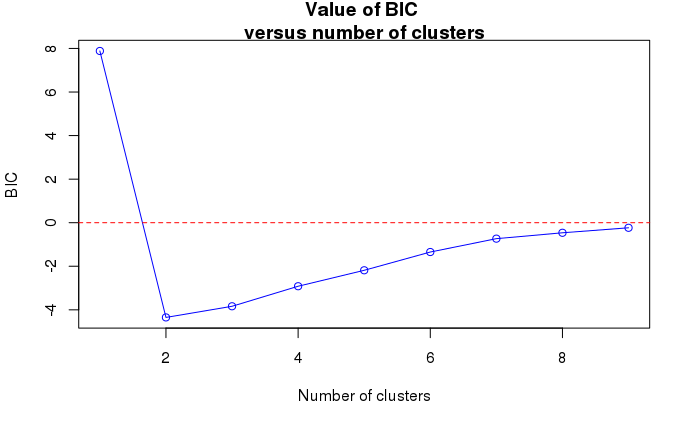

```r
2
```

```r
save(clusters,file = 'temporary_data/clusters_DAPC.RData')
```

Let’s load the object above if this is a re-run of this notebook. It turns out that adegenet does not include sample names if there is only one cluster, so we have to standardize that before proceeding

```r
load('temporary_data/clusters_DAPC.RData')
clusters = spp %>%
  plyr::llply(function(i_sp){
    result = clusters[[i_sp]]
    if(is.null(names(result$grp))){
      names(result$grp) = sample_names %>% filter(taxon == i_sp) %>% pull(sample)
    }
    return(result)
  })
str(clusters,max.level = 1)
```

```
List of 13
 $ Anchylorhynchus_1:List of 4
 $ Anchylorhynchus_2:List of 4
 $ Anchylorhynchus_3:List of 4
 $ Andranthobius_1  :List of 4
 $ Andranthobius_2  :List of 4
 $ C_decolor_1      :List of 4
 $ C_decolor_2      :List of 4
 $ C_impar          :List of 4
 $ D_polyphaga      :List of 4
 $ M_bondari_1      :List of 4
 $ M_ypsilon        :List of 4
 $ P_cocoseae       :List of 4
 $ R_rectinasus_1   :List of 4
```

Now that we have clusters, let’s visualize them in a PCA plot. For that, let’s first create a data.frame including information about species, group assignment and PCA axes 1-2

```r
PCA_df = spp %>%
  plyr::ldply(function(i_sp){
    PCA_axes = eig[[i_sp]]$vectors[,1:2] %>%
      as.data.frame %>%
      rename(PC1 = 1, PC2 = 2) %>%
      mutate(PC1 = PC1 * sqrt(eig[[i_sp]]$values[1]),
             PC2 = PC2 * sqrt(eig[[i_sp]]$values[2]),
             cluster = clusters[[i_sp]]$grp) %>%
      bind_cols(filter(sample_names, taxon == i_sp)) %>%
      dplyr::select(-taxon) #will be added automatically
  },
  .parallel = FALSE) %>%
  rename(taxon = .id)
PCA_df
```

| taxon | PC1 | PC2 | cluster | sample |
| --- | --- | --- | --- | --- |
| Anchylorhynchus_1 | 0.310188078 | -9.677825e-01 | 2 | BdM1012 |
| Anchylorhynchus_1 | 0.322120368 | -9.599036e-01 | 2 | BdM1013 |
| Anchylorhynchus_1 | 0.326509193 | -9.902016e-01 | 2 | BdM1014 |
| Anchylorhynchus_1 | 0.323337924 | -9.929260e-01 | 2 | BdM1015 |
| Anchylorhynchus_1 | 0.322613876 | -9.700992e-01 | 2 | BdM1016 |
| Anchylorhynchus_1 | 0.311113020 | -9.565794e-01 | 2 | BdM1017 |
| Anchylorhynchus_1 | 0.320158721 | -9.646418e-01 | 2 | BdM1018 |
| Anchylorhynchus_1 | 0.325272012 | -9.786443e-01 | 2 | BdM1019 |
| Anchylorhynchus_1 | 0.339531039 | 2.617265e-01 | 1 | BdM1031 |
| Anchylorhynchus_1 | 0.355202581 | 2.515033e-01 | 1 | BdM1034 |

[output cut: 326 more lines]

Before plotting, let’s create a vector to produce nice species names in the output:

```r
names_translation = c('Anchylorhynchus_1' = "italic(Anc.~trapezicollis)~OTU~1",
                     'Anchylorhynchus_2' = "italic(Anc.~trapezicollis)~OTU~2",
                     'Anchylorhynchus_3' = "italic(Anc.~trapezicollis)~OTU~3",
                     'Andranthobius_1' = "italic(And.~bondari)~OTU~1",
                     'Andranthobius_2' = "italic(And.~bondari)~OTU~2",
                     'C_decolor_1' = "italic(C.~decolor)~OTU~1",
                     'C_decolor_2' = "italic(C.~decolor)~OTU~2",
                     'C_impar' = "italic(C.~impar)",
                     'D_polyphaga' = "italic(D.~polyphaga)",
                     'M_bondari_1' = "italic(M.~bondari)~OTU~1",
                     'M_bondari_2' = "italic(M.~bondari)~OTU~2",
                     'M_ypsilon' = "italic(M.~ypsilon)",
                     'P_cocoseae' = "italic(P.~cocoseae)",
                     'R_rectinasus_1' = "italic(R.~rectinasus)",
                     'Syagrus_coronata' = "italic(Syagrus~coronata)",
                     'Syagrus_botryophora' = "italic(Syagrus~botryophora)"
                     )
```

Now let’s plot all PCA and save as a supplementary figure

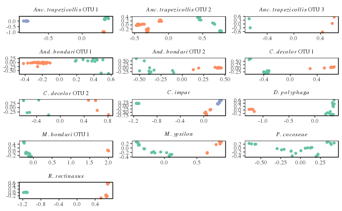

```r
p = ggplot(PCA_df) +
  geom_point(aes(x = PC1, y = PC2, color = cluster)) +
  facet_wrap(~taxon,
             scales = 'free',
             labeller = as_labeller(names_translation, default = label_parsed),
             ncol=3
             ) +
  scale_color_brewer(type='qual', guide = 'none',palette = 'Set2') +
  theme_tufte() +
  theme(axis.title = element_blank(),
        panel.border = element_rect(color='black',fill=NA))
print(p)
```

# Mapping PCA axes

Now lets plot PCAs in a map. First, we need to get coordinates for our samples.

We will also keep the single record of M. bondari in Syagrus coronata.

In this case, since it is a single specimen, we do not have a dataset, but we would still like to map it.

```r
PCA_map_df = readr::read_csv('sample_info/sample_data.csv') %>%
  dplyr::select(sample=genomics_id,
         plant_species,
         lat,
         lon) %>%
  distinct() %>% #for some reason, a few records are duplicated
  right_join(PCA_df %>% bind_rows(tibble(taxon = 'M_bondari_2',
                                         sample = 'BdM1049',
                                         cluster = '1',
                                         PC1 = 0,
                                         PC2 = 0))
             )
PCA_map_df
```

| sample | plant_species | lat | lon | taxon | PC1 | PC2 | cluster |
| --- | --- | --- | --- | --- | --- | --- | --- |
| BdM1012 | coronata | -16.146382 | -40.20850 | Anchylorhynchus_1 | 0.310188078 | -9.677825e-01 | 2 |
| BdM1013 | coronata | -16.146382 | -40.20850 | Anchylorhynchus_1 | 0.322120368 | -9.599036e-01 | 2 |
| BdM1014 | coronata | -16.146382 | -40.20850 | Anchylorhynchus_1 | 0.326509193 | -9.902016e-01 | 2 |
| BdM1015 | coronata | -16.146382 | -40.20850 | Anchylorhynchus_1 | 0.323337924 | -9.929260e-01 | 2 |
| BdM1016 | coronata | -16.146382 | -40.20850 | Anchylorhynchus_1 | 0.322613876 | -9.700992e-01 | 2 |
| BdM1017 | coronata | -16.146382 | -40.20850 | Anchylorhynchus_1 | 0.311113020 | -9.565794e-01 | 2 |
| BdM1018 | coronata | -16.146382 | -40.20850 | Anchylorhynchus_1 | 0.320158721 | -9.646418e-01 | 2 |
| BdM1019 | coronata | -16.146382 | -40.20850 | Anchylorhynchus_1 | 0.325272012 | -9.786443e-01 | 2 |
| BdM1031 | coronata | -12.461433 | -40.56579 | Anchylorhynchus_1 | 0.339531039 | 2.617265e-01 | 1 |
| BdM1034 | coronata | -11.628955 | -41.15310 | Anchylorhynchus_1 | 0.355202581 | 2.515033e-01 | 1 |

[output cut: 327 more lines]

```r
rgb_cols = function(df){
  x = scales::rescale(df$PC1, from = range(df[c('PC1','PC2')]),  to = c(-100,100))
  y = scales::rescale(df$PC2, from = range(df[c('PC1','PC2')]),  to = c(-100,100))
  l = sqrt(x^2+y^2)/sqrt(2*100^2)*40+50

  data.frame(L = l,
             U = y,
             V = x
  ) %>%
    convertColor(., from = 'Luv', to = 'sRGB') %>%
    rgb() %>%
    data.frame(sample = df$sample , color=.)
}
```

Now apply the function. We will do a trick to paint M_bondari_2 black:

```r
PCA_map_df = PCA_map_df %>%
  group_by(taxon) %>%
  do(rgb_cols(.)) %>%
  ungroup %>%
  dplyr::select(sample, color) %>%
  right_join(PCA_map_df)
color_scale = as.character(PCA_map_df$color)
names(color_scale) = 1:length(PCA_map_df$color)
color_scale['black'] = '#000000'
PCA_map_df$color = as.character(1:length(PCA_map_df$color))
PCA_map_df$color[PCA_map_df$sample == 'BdM1049'] = 'black'
PCA_map_df
```

| sample | color | plant_species | lat | lon | taxon | PC1 | PC2 | cluster |
| --- | --- | --- | --- | --- | --- | --- | --- | --- |
| BdM1012 | 1 | coronata | -16.146382 | -40.20850 | Anchylorhynchus_1 | 0.310188078 | -9.677825e-01 | 2 |
| BdM1013 | 2 | coronata | -16.146382 | -40.20850 | Anchylorhynchus_1 | 0.322120368 | -9.599036e-01 | 2 |
| BdM1014 | 3 | coronata | -16.146382 | -40.20850 | Anchylorhynchus_1 | 0.326509193 | -9.902016e-01 | 2 |
| BdM1015 | 4 | coronata | -16.146382 | -40.20850 | Anchylorhynchus_1 | 0.323337924 | -9.929260e-01 | 2 |
| BdM1016 | 5 | coronata | -16.146382 | -40.20850 | Anchylorhynchus_1 | 0.322613876 | -9.700992e-01 | 2 |
| BdM1017 | 6 | coronata | -16.146382 | -40.20850 | Anchylorhynchus_1 | 0.311113020 | -9.565794e-01 | 2 |
| BdM1018 | 7 | coronata | -16.146382 | -40.20850 | Anchylorhynchus_1 | 0.320158721 | -9.646418e-01 | 2 |
| BdM1019 | 8 | coronata | -16.146382 | -40.20850 | Anchylorhynchus_1 | 0.325272012 | -9.786443e-01 | 2 |
| BdM1031 | 9 | coronata | -12.461433 | -40.56579 | Anchylorhynchus_1 | 0.339531039 | 2.617265e-01 | 1 |
| BdM1034 | 10 | coronata | -11.628955 | -41.15310 | Anchylorhynchus_1 | 0.355202581 | 2.515033e-01 | 1 |

[output cut: 327 more lines]

Now, let’s download a base map from Natural Earth (commented ou if already done)

```r
basemap = ne_download(scale = 'large', type = 'GRAY_HR_SR_OB_DR', category = 'raster', destdir = './map')
```

After map is downloaded, let’s crop it to the region of interest:

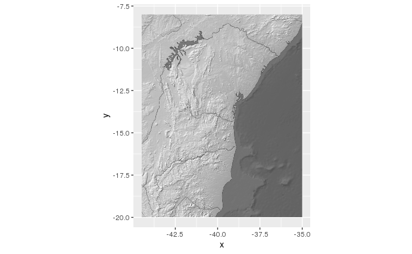

```r
basemap = raster::stack('map/GRAY_HR_SR_OB_DR/GRAY_HR_SR_OB_DR.tif')
bbox = raster::extent(c(xmin=-44.5,xmax=-35,ymin=-20,ymax=-8))
cropped = raster::crop(basemap,bbox)
map_layer = ggRGB(cropped, ggLayer = TRUE,r = 1,g=1,b=1)
#the following is just to visualize the layer
ggRGB(cropped, r = 1,g=1,b=1) %>%
  print
```

And plot:

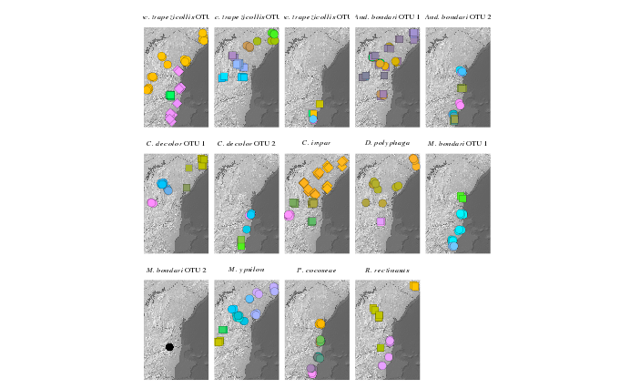

```r
ggplot(PCA_map_df) +
  map_layer +
  geom_jitter(aes(x = lon,
                  y = lat,
                  fill = color,
                  shape = cluster),
              width=0.2,
              height=0.2,
              size = 3,
              stroke=0.1) +
  scale_fill_manual(values = color_scale, guide = F) +
  scale_shape_manual(values = 21:23, guide = F) +
  facet_wrap(~taxon,
             labeller = as_labeller(names_translation, default = label_parsed),
             ncol=5) +
  theme_tufte() +
  theme(axis.title = element_blank(),
        axis.text = element_blank(),
        axis.ticks = element_blank(),
        strip.text = element_text(size=6)) +
  coord_equal()
```

Now we will do a similar plot, but with plant species as shapes.

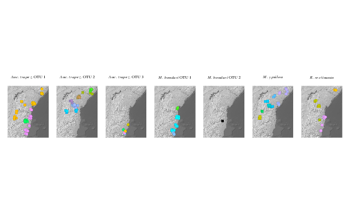

```r
names_translation2 = c('Anchylorhynchus_1' = "italic(Anc.~trapez.)~OTU~1",
                     'Anchylorhynchus_2' = "italic(Anc.~trapez.)~OTU~2",
                     'Anchylorhynchus_3' = "italic(Anc.~trapez.)~OTU~3",
                     'Andranthobius_1' = "italic(And.~bondari)~OTU~1",
                     'Andranthobius_2' = "italic(And.~bondari)~OTU~2",
                     'C_decolor_1' = "italic(C.~decolor)~OTU~1",
                     'C_decolor_2' = "italic(C.~decolor)~OTU~2",
                     'C_impar' = "italic(C.~impar)",
                     'D_polyphaga' = "italic(D.~polyphaga)",
                     'M_bondari_1' = "italic(M.~bondari)~OTU~1",
                     'M_bondari_2' = "italic(M.~bondari)~OTU~2",
                     'M_ypsilon' = "italic(M.~ypsilon)",
                     'P_cocoseae' = "italic(P.~cocoseae)",
                     'R_rectinasus_1' = "italic(R.~rectinasus)"
                     )
p = PCA_map_df %>%
  filter(taxon %in% c('Anchylorhynchus_1','Anchylorhynchus_2','Anchylorhynchus_3','M_bondari_1', 'M_bondari_2', 'R_rectinasus_1','M_ypsilon')) %>%
  arrange(plant_species,abs(PC1)*abs(PC2)) %>%
  ggplot +
  map_layer +
  geom_jitter(aes(x = lon,
                  y = lat,
                  fill = color,
                  shape = plant_species),
              width=0.3,
              height=0.3,
              size = 2,
              stroke=0.05) +
  scale_fill_manual(values = color_scale, guide = F) +
  scale_shape_manual(values = 21:23, guide = F) +
  facet_wrap(~taxon,
             labeller = as_labeller(names_translation2, default = label_parsed),
             ncol=7) +
  theme_tufte() +
  theme(axis.title = element_blank(),
        axis.text = element_blank(),
        axis.ticks = element_blank(),
        strip.text = element_text(size=6)) +
  coord_equal(xlim = c(bbox@xmin,bbox@xmax),
              ylim = c(bbox@ymin,bbox@ymax))
print(p)
ggsave(filename = 'figures/PCA_map_pollant.pdf',
       plot = p,
       device = 'pdf',
       height = 4.5,
       width=17.8,
       units = 'cm',
       useDingbats=F)
```

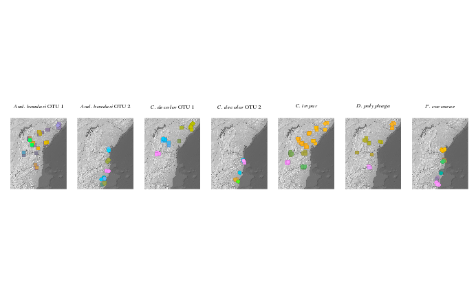

```r
p = PCA_map_df %>%
  filter(taxon %in% c('Andranthobius_1', 'Andranthobius_2', 'C_decolor_1','C_decolor_2','C_impar','D_polyphaga','P_cocoseae')) %>%
  arrange(plant_species,abs(PC1)*abs(PC2)) %>%
  ggplot +
  map_layer +
  geom_jitter(aes(x = lon,
                  y = lat,
                  fill = color,
                  shape = plant_species),
              width=0.3,
              height=0.3,
              size = 2,
              stroke=0.05) +
  scale_fill_manual(values = color_scale, guide = F) +
  scale_shape_manual(values = 21:23, guide = F) +
  facet_wrap(~taxon,
             labeller = as_labeller(names_translation2, default = label_parsed),
             ncol=7) +
  theme_tufte() +
  theme(axis.title = element_blank(),
        axis.text = element_blank(),
        axis.ticks = element_blank(),
        strip.text = element_text(size=6)) +
  coord_equal(xlim = c(bbox@xmin,bbox@xmax),
              ylim = c(bbox@ymin,bbox@ymax))
print(p)
ggsave(filename = 'figures/PCA_map_commensals.pdf',
       plot = p,
       device = 'pdf',
       height = 4.5,
       width=17.8,
       units = 'cm',
       useDingbats=F)
```

We will manually insert some information in this graph using Adobe Illustrator: * variance explained by PC axes * spatial extent of k-means clusters * an inset with color space mapped on PC axes

The following are blocks of code to generate this information:

Starting by variance explained:

```r
PC_text = plyr::llply(eig,
            function(x){
              perc = x$values/sum(x$values)
              paste(c('PC1: ','PC2: '),100*perc[1:2] %>% round(digits = 3),'%\n',sep='',collapse='') %>%
                paste('\n',sep='')
            })
PC_text %>% plyr::l_ply(cat)
```

```
PC1: 22.1%
PC2: 15.4%

PC1: 20%
PC2: 3.9%

PC1: 36.7%
PC2: 20.3%

PC1: 8.7%
PC2: 3.1%

PC1: 13.9%
PC2: 4.9%

PC1: 21.3%
PC2: 8.4%

PC1: 28.3%
PC2: 12.7%

PC1: 17.9%
PC2: 10.9%

PC1: 33.4%
PC2: 5.8%

PC1: 30.1%
PC2: 5.3%

PC1: 19.6%
PC2: 4.4%

PC1: 9.6%
PC2: 5%

PC1: 51.7%
PC2: 4.9%
```

Now let’s list populations for each k-means cluster:

```r
PCA_map_df %>%
  mutate(cluster = LETTERS[as.integer(cluster)]) %>%
  left_join(readr::read_csv('sample_info/sample_data.csv') %>%
              dplyr::select(sample=genomics_id,population=pop_id_thesis)) %>%
  group_by(taxon,cluster) %>%
  summarise(pops=paste(unique(population),collapse=','))
```

| taxon | cluster | pops |
| --- | --- | --- |
| Anchylorhynchus_1 | A | P5,P6,P7,P9,P15,P13,P17_cor |
| Anchylorhynchus_1 | B | P2 |
| Anchylorhynchus_1 | C | P1,P3,P8,P10,P12 |
| Anchylorhynchus_2 | A | P19,P15,P20,P17_cor,P17_hyb |
| Anchylorhynchus_2 | B | P4,P5,P6,P7,P11 |
| Anchylorhynchus_3 | A | P8 |
| Anchylorhynchus_3 | B | P1,P10 |
| Andranthobius_1 | A | P2,P4,P5,P6,P20,P13 |
| Andranthobius_1 | B | P2,P4,P11,P5,P6,P15,P7,P17_cor,P20,P13,P17_hyb,P19 |
| Andranthobius_2 | A | P1,P10,P12 |

[output cut: 18 more lines]

```r
NA
```

For reference, these are the population coordinates:

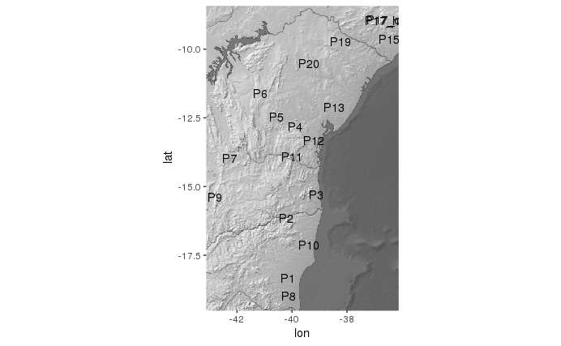

```r
pop_locs = readr::read_csv('sample_info/sample_data.csv') %>%
              dplyr::select(population=pop_id_thesis, lat, lon) %>%
  group_by(population) %>%
  summarize_all(mean)
ggplot(pop_locs, aes(x=lon,y=lat)) +
  map_layer +
  geom_text(aes(label=population)) +
  coord_equal()
```

```r
NA
NA
```

Let’s also plot a graph that will work as a guide:

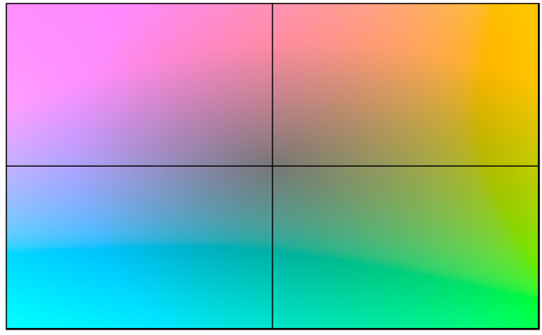

```r
key_df = tibble(PC1=seq(-50,50),PC2=seq(-50,50)) %>%
  #filter(Axis1 != 0 & Axis2 != 0) %>%
  expand(crossing(PC1,PC2)) %>%
  mutate(sample=1:dim(.)[1])
key_df = key_df %>%
  left_join(rgb_cols(key_df))
colors = unique(as.character(key_df$color))
names(colors) = colors
p = ggplot(key_df, aes(PC1,PC2)) +
  geom_raster(aes(fill=as.character(color)), interpolate = TRUE) +
  geom_hline(aes(yintercept=0)) +
  geom_vline(aes(xintercept=0)) +
  scale_fill_manual(values=colors, guide='none') +
  scale_x_continuous(expand=c(0,0)) +
  scale_y_continuous(expand=c(0,0)) +
  theme(plot.margin = margin(1,1,1,1,unit = 'mm'),
        axis.title = element_blank(),
        axis.line = element_blank(),
        axis.text = element_blank(),
        axis.ticks = element_blank(),
        panel.border = element_rect(fill=NA,colour = 'black',size=1)) +
  coord_cartesian()
print(p)
ggsave(filename = 'figures/PCA_map_guide.pdf',
       plot = p,
       device = 'pdf',
       width = 80,
       height = 60,
       units = 'mm',
       useDingbats=F)
```

# Plant PCA

Our map will also include the range of each plant species and a PCA with their genetic variation.

Let’s load plant data, do the PCA and translate to colors. We will do PCA separately for each species of plant since they are completely isolated.

```r
plant_spp = c('coronata','botryophora')
names(plant_spp) = str_c('Syagrus_',plant_spp)
plant_specimens = plant_spp %>%
  sapply(function(x){
    list.files(file.path('..','ANGSD_plants',x),
               pattern = 'bam.filelist',
               recursive = T,
               full.names = T) %>%
      file() %>%
      readLines() %>%
      basename() %>%
      str_remove_all('\\..+$')
  }) %>%
  unlist
plant_sample_names = tibble(sample = plant_specimens,
                      taxon = names(plant_specimens) %>% str_remove('[0-9]+$'))
plant_sample_names
```

| sample | taxon |
| --- | --- |
| BdM1590 | Syagrus_coronata |
| BdM1592 | Syagrus_coronata |
| BdM1594 | Syagrus_coronata |
| BdM1607 | Syagrus_coronata |
| BdM1637 | Syagrus_coronata |
| BdM1638 | Syagrus_coronata |
| BdM1639 | Syagrus_coronata |
| BdM1656 | Syagrus_coronata |
| BdM1658 | Syagrus_coronata |
| BdM1662 | Syagrus_coronata |

[output cut: 64 more lines]

Now let’s add covariances to the table.

```r
plant_covs = plant_spp %>%
  plyr::llply(function(x){
    list.files(file.path('..','ANGSD_plants',x),
               pattern = 'pca\\.cov',
               recursive = T,
               full.names = T) %>%
      file %>%
      readr::read_lines() %>%
      plyr::laply(str_split,'[:space:]',simplify = T) %>%
      as.numeric %>%
      matrix(.,nrow=sqrt(length(.)))
  })
str(plant_covs)
```

```
List of 2
 $ Syagrus_coronata   : num [1:49, 1:49] 1.3447 0.0194 -0.1047 -0.1934 -0.0922 ...
 $ Syagrus_botryophora: num [1:25, 1:25] 1.0255 -0.2626 0.0993 0.0881 0.085 ...
```

Now we will do the PCA based on the covariance matrices.

```r
plant_eig = plyr::llply(plant_covs, eigen, symmetric = T)
names(plant_eig) = plant_spp
str(plant_eig)
```

```
List of 2
 $ coronata   :List of 2
  ..$ values : num [1:49] 7.39 1.95 1.74 1.46 1.43 ...
  ..$ vectors: num [1:49, 1:49] -0.1946 -0.0326 0.0735 0.1566 0.0658 ...
  ..- attr(*, "class")= chr "eigen"
 $ botryophora:List of 2
  ..$ values : num [1:25] 7.88 1.92 1.57 1.42 0.98 ...
  ..$ vectors: num [1:25, 1:25] 0.136 -0.25 0.161 0.135 0.155 ...
  ..- attr(*, "class")= chr "eigen"
```

Here we combine PCA results with sample names.

```r
plant_PCA_df = plant_spp %>%
  plyr::ldply(function(i_sp){
    plant_eig[[i_sp]]$vectors[,1:2] %>%
      as.data.frame %>%
      rename(PC1 = 1, PC2 = 2) %>%
      mutate(PC1 = PC1 * sqrt(plant_eig[[i_sp]]$values[1]),
             PC2 = PC2 * sqrt(plant_eig[[i_sp]]$values[2])) %>%
      bind_cols(filter(plant_sample_names, taxon == str_c('Syagrus_', i_sp))) %>%
      dplyr::select(-taxon) #will be added automatically
  },
  .parallel = FALSE) %>%
  rename(taxon = .id)
plant_PCA_df
```

| taxon | PC1 | PC2 | sample |
| --- | --- | --- | --- |
| Syagrus_coronata | -0.52901808 | 1.138109e-01 | BdM1590 |
| Syagrus_coronata | -0.08865987 | -7.711304e-02 | BdM1592 |
| Syagrus_coronata | 0.19987877 | -1.088726e-01 | BdM1594 |
| Syagrus_coronata | 0.42578643 | -1.044547e-02 | BdM1607 |
| Syagrus_coronata | 0.17886979 | -1.206228e-01 | BdM1637 |
| Syagrus_coronata | 0.42594934 | -3.353163e-02 | BdM1638 |
| Syagrus_coronata | 0.40340869 | 6.920950e-01 | BdM1639 |
| Syagrus_coronata | 0.40357585 | 1.654827e-01 | BdM1656 |
| Syagrus_coronata | -0.01082298 | -8.739421e-02 | BdM1658 |
| Syagrus_coronata | -0.52121576 | 1.089934e-01 | BdM1662 |

[output cut: 64 more lines]

Let’s add now location data.

```r
plant_PCA_map_df = readr::read_csv('sample_info/Syagrus_data.csv') %>%
  dplyr::select(sample=genomics,
         plant_species,
         lat,
         lon,
         pop_id_thesis) %>%
  distinct() %>% #for some reason, a few records are duplicated
  right_join(plant_PCA_df)

plant_PCA_map_df
```

| sample | plant_species | lat | lon | pop_id_thesis | taxon | PC1 | PC2 |
| --- | --- | --- | --- | --- | --- | --- | --- |
| BdM1590 | coronata | -15.389457 | -42.80203 | P9 | Syagrus_coronata | -0.52901808 | 1.138109e-01 |
| BdM1592 | coronata | -12.454400 | -40.54800 | P5 | Syagrus_coronata | -0.08865987 | -7.711304e-02 |
| BdM1594 | coronata | -10.536483 | -39.37708 | P20 | Syagrus_coronata | 0.19987877 | -1.088726e-01 |
| BdM1607 | coronata | -9.760979 | -36.50717 | P15 | Syagrus_coronata | 0.42578643 | -1.044547e-02 |
| BdM1637 | coronata | -11.628016 | -41.15346 | P6 | Syagrus_coronata | 0.17886979 | -1.206228e-01 |
| BdM1638 | coronata | -9.740904 | -38.23869 | P19 | Syagrus_coronata | 0.42594934 | -3.353163e-02 |
| BdM1639 | x costae | -8.976726 | -36.51673 | P17_hyb | Syagrus_coronata | 0.40340869 | 6.920950e-01 |
| BdM1656 | coronata | -8.931129 | -36.49731 | P17_cor | Syagrus_coronata | 0.40357585 | 1.654827e-01 |
| BdM1658 | coronata | -12.454400 | -40.54800 | P5 | Syagrus_coronata | -0.01082298 | -8.739421e-02 |
| BdM1662 | coronata | -15.391130 | -42.80124 | P9 | Syagrus_coronata | -0.52121576 | 1.089934e-01 |

[output cut: 64 more lines]

Now let’s add a column mapping PCA coordinates to colors

```r
plant_PCA_map_df = plant_PCA_map_df %>%
  group_by(taxon) %>%
  do(rgb_cols(.)) %>%
  ungroup %>%
  dplyr::select(sample, color) %>%
  right_join(plant_PCA_map_df)
```

[output not shown]

```r
plant_color_scale = as.character(plant_PCA_map_df$color)
names(plant_color_scale) = 1:length(plant_PCA_map_df$color)
plant_PCA_map_df$color = as.character(1:length(plant_PCA_map_df$color))
plant_PCA_map_df
```

| sample | color | plant_species | lat | lon | pop_id_thesis | taxon | PC1 | PC2 |
| --- | --- | --- | --- | --- | --- | --- | --- | --- |
| BdM1590 | 1 | coronata | -15.389457 | -42.80203 | P9 | Syagrus_coronata | -0.52901808 | 1.138109e-01 |
| BdM1592 | 2 | coronata | -12.454400 | -40.54800 | P5 | Syagrus_coronata | -0.08865987 | -7.711304e-02 |
| BdM1594 | 3 | coronata | -10.536483 | -39.37708 | P20 | Syagrus_coronata | 0.19987877 | -1.088726e-01 |
| BdM1607 | 4 | coronata | -9.760979 | -36.50717 | P15 | Syagrus_coronata | 0.42578643 | -1.044547e-02 |
| BdM1637 | 5 | coronata | -11.628016 | -41.15346 | P6 | Syagrus_coronata | 0.17886979 | -1.206228e-01 |
| BdM1638 | 6 | coronata | -9.740904 | -38.23869 | P19 | Syagrus_coronata | 0.42594934 | -3.353163e-02 |
| BdM1639 | 7 | x costae | -8.976726 | -36.51673 | P17_hyb | Syagrus_coronata | 0.40340869 | 6.920950e-01 |
| BdM1656 | 8 | coronata | -8.931129 | -36.49731 | P17_cor | Syagrus_coronata | 0.40357585 | 1.654827e-01 |
| BdM1658 | 9 | coronata | -12.454400 | -40.54800 | P5 | Syagrus_coronata | -0.01082298 | -8.739421e-02 |
| BdM1662 | 10 | coronata | -15.391130 | -42.80124 | P9 | Syagrus_coronata | -0.52121576 | 1.089934e-01 |

[output cut: 64 more lines]

Before mapping, let’s have a look at the PCAs:

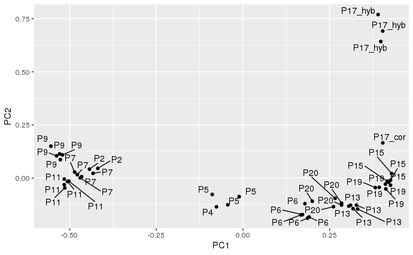

```r
ggplot(plant_PCA_map_df %>% filter(taxon == 'Syagrus_coronata')) +
  geom_point(aes(x=PC1,y=PC2)) +
  geom_text_repel(aes(x=PC1,y=PC2,label=pop_id_thesis))
```

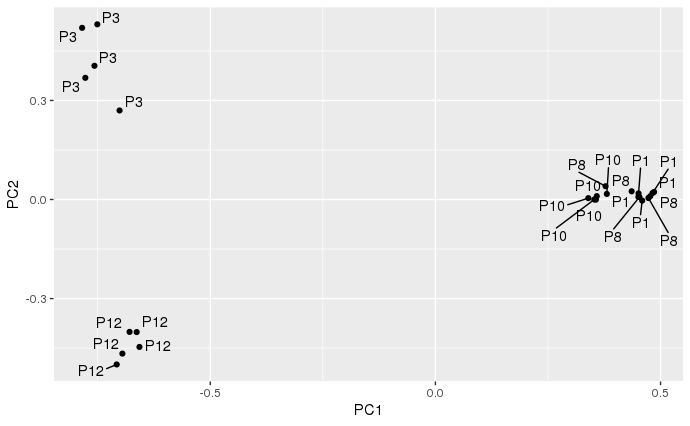

```r
ggplot(plant_PCA_map_df %>% filter(taxon == 'Syagrus_botryophora')) +
  geom_point(aes(x=PC1,y=PC2)) +
  geom_text_repel(aes(x=PC1,y=PC2,label=pop_id_thesis))
```

Now let’s obtain the map of South America where we will place plant samples.

```r
bbox = raster::extent(c(xmin=-44,
              xmax=-35,
              ymin=-20,
              ymax=-8.5)) %>%
  as('SpatialPolygons')
crs(bbox) = crs(basemap)
bbox = st_as_sf(bbox)

cropped_Brazil = raster::crop(basemap,raster::extent(c(xmin=-83,xmax=-33,ymin=-30,ymax=0)))
map_extent_sf = raster::extent(c(xmin=-83,xmax=-33,ymin=-31,ymax=1)) %>%
  as('SpatialPolygons') %>%
  st_as_sf() %>%
  st_set_crs(as.character(crs(cropped_Brazil)))

countries = ne_countries(scale=50, returnclass = 'sf') %>%
  st_transform(as.character(crs(cropped_Brazil))) %>%
  st_intersection(map_extent_sf)
```

```
although coordinates are longitude/latitude, st_intersection assumes that they are planar
attribute variables are assumed to be spatially constant throughout all geometries
```

Now, let’s plot a map including plant samples:

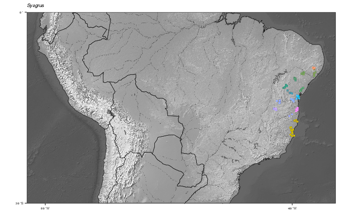

```r
p = ggRGB(cropped_Brazil, r = 1,g=1,b=1) +
  geom_sf(color='black',fill=NA, size=0.2, data=countries) +
  #geom_sf(data=bbox,fill=NA) +
  #geom_sf(data=bbox,fill=NA,color='black') +
  coord_sf() +
  theme_few() +
  xlab(NULL) +
  ylab(NULL) +
  scale_x_continuous(expand = c(0,0),
                     breaks=c(-80,-40),limits = c(-83,-33)) +
  scale_y_continuous(expand = c(0,0),
                     breaks=c(0,-30),limits = c(-30,0)) +
  geom_jitter(aes(x = lon,
                  y = lat,
                  fill = color,
                  shape = plant_species),
              data = plant_PCA_map_df,
              width=0.3,
              height=0.3,
              size = 1.5,
              stroke=0.05) +
  scale_shape_manual(values = 21:23, guide = F) +
  scale_fill_manual(values = plant_color_scale, guide=F) +
  ggtitle('Syagrus') +
  theme(text = element_text(size=6,face = 'italic'),
        panel.grid = element_blank(),
        plot.background = element_rect(fill = "transparent", color = NA),
        plot.margin = margin(t = 5.5,
                             r = 5.5,
                             b = 5.5,
                             l = 10))
p
ggsave(filename = 'figures/PCA_map_Syagrus.pdf',
       plot = p,
       device = 'pdf',
       width = 80,
       height = 45,
       units = 'mm',
       useDingbats=F)
```

Finally, let’s also split plants by kmeans and make a single PCA plot with all species, plants ants insects.

```r
set.seed(15897)
plant_clusters = plant_spp %>%
  plyr::llply(function(x){
    find.clusters.eigen(plant_eig[[x]],
                  pca.select = 'percVar',
                  perc.pca=90,
                  max.n.clust = min(10, length(plant_eig[[x]]$values)%/%2))
  },
  .parallel = FALSE)
```

```
Choose the number of clusters (>=2:
```

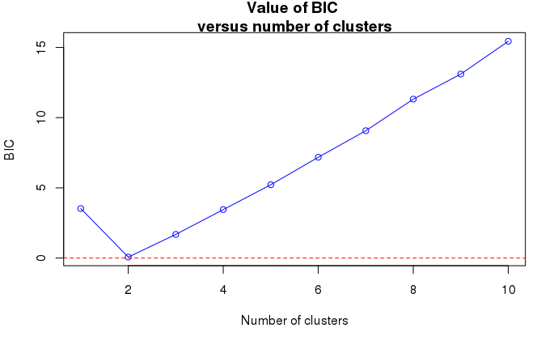

```
Choose the number of clusters (>=2:
```

```r
2
```

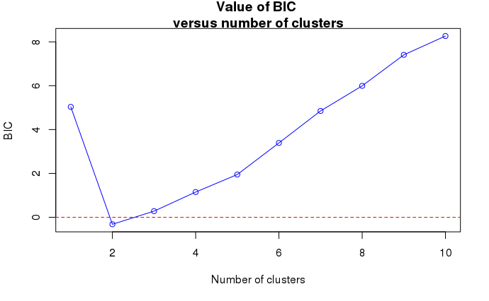

```r
2
```

```r
save(plant_clusters,file = 'temporary_data/plant_clusters_DAPC.RData')
```

```r
load(file = 'temporary_data/plant_clusters_DAPC.RData')
names(plant_clusters) = names(plant_covs)
names(plant_eig) = names(plant_covs)
plant_spp = names(plant_covs)
names(plant_spp) = plant_spp
plant_PCA_df = plant_spp %>%
  plyr::ldply(function(i_sp){
    PCA_axes = plant_eig[[i_sp]]$vectors[,1:2] %>%
      as.data.frame %>%
      rename(PC1 = 1, PC2 = 2) %>%
      mutate(PC1 = PC1 * sqrt(plant_eig[[i_sp]]$values[1]),
             PC2 = PC2 * sqrt(plant_eig[[i_sp]]$values[2]),
             cluster = plant_clusters[[i_sp]]$grp) %>%
      bind_cols(filter(plant_sample_names, taxon == i_sp)) %>%
      dplyr::select(-taxon) #will be added automatically
  },
  .parallel = FALSE) %>%
  rename(taxon = .id)
plant_PCA_df
```

| taxon | PC1 | PC2 | cluster | sample |
| --- | --- | --- | --- | --- |
| Syagrus_coronata | -0.52901808 | 1.138109e-01 | 2 | BdM1590 |
| Syagrus_coronata | -0.08865987 | -7.711304e-02 | 1 | BdM1592 |
| Syagrus_coronata | 0.19987877 | -1.088726e-01 | 1 | BdM1594 |
| Syagrus_coronata | 0.42578643 | -1.044547e-02 | 1 | BdM1607 |
| Syagrus_coronata | 0.17886979 | -1.206228e-01 | 1 | BdM1637 |
| Syagrus_coronata | 0.42594934 | -3.353163e-02 | 1 | BdM1638 |
| Syagrus_coronata | 0.40340869 | 6.920950e-01 | 1 | BdM1639 |
| Syagrus_coronata | 0.40357585 | 1.654827e-01 | 1 | BdM1656 |
| Syagrus_coronata | -0.01082298 | -8.739421e-02 | 1 | BdM1658 |
| Syagrus_coronata | -0.52121576 | 1.089934e-01 | 2 | BdM1662 |

[output cut: 64 more lines]

Let’s now print a graph with PCAs and k-means clusters for all species to use as supplementary material.

```r
p = ggplot(PCA_df %>% bind_rows(plant_PCA_df)) +
  geom_point(aes(x = PC1, y = PC2, color = cluster)) +
  facet_wrap(~taxon,
             scales = 'free',
             labeller = as_labeller(names_translation, default = label_parsed),
             ncol=3
             ) +
  scale_color_brewer(type='qual', guide = 'none',palette = 'Set2') +
  theme_tufte() +
  theme(axis.title = element_blank(),
        panel.border = element_rect(color='black',fill=NA))
```

```
Unequal factor levels: coercing to characterbinding character and factor vector, coercing into character vectorbinding character and factor vector, coercing into character vector
```

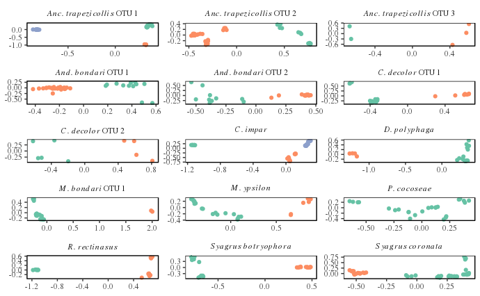

```r
print(p)
ggsave(filename = 'figures/supp_PCA.pdf',
       plot = p,
       device = 'pdf',
       width = 168,
       height = 168,
       units = 'mm',
       useDingbats=F)
```

The covariance explained by plant PC axes is:

```r
plyr::llply(plant_eig,
            function(x){
              perc = x$values/sum(x$values)
              paste(c('PC1: ','PC2: '),100*perc[1:2] %>% round(digits = 3),'%\n',sep='',collapse='') %>%
                paste('\n',sep='')
            }) %>% plyr::l_ply(cat)
```

```
PC1: 13.8%
PC2: 3.6%

PC1: 27%
PC2: 6.6%
```

# Prepare for fastsimcoal

Now the question is: is there gene flow between clusters? We will use fastsimcoal to test that. To help producing the input files needed, let’s output a table with the assignment of each sample to a population, following the k-means clustering:

```r
tb1 = PCA_df %>%
  transmute(taxon,
            sample,
            cluster = LETTERS[cluster]) %>%
  arrange(taxon,cluster,sample)
tb1
```

| taxon | sample | cluster |
| --- | --- | --- |
| Anchylorhynchus_1 | BdM1031 | A |
| Anchylorhynchus_1 | BdM1034 | A |
| Anchylorhynchus_1 | BdM1035 | A |
| Anchylorhynchus_1 | BdM1038 | A |
| Anchylorhynchus_1 | BdM1041 | A |
| Anchylorhynchus_1 | BdM1044 | A |
| Anchylorhynchus_1 | BdM1045 | A |
| Anchylorhynchus_1 | BdM1046 | A |
| Anchylorhynchus_1 | BdM1047 | A |
| Anchylorhynchus_1 | BdM1048 | A |

[output cut: 326 more lines]

```r
readr::write_csv(tb1, path = 'results/DAPC_clusters.csv')
```